# BIOS 611 HW1 Data visualisation (Chapter 3)

# Exercise 4

   Answer: The default gein fir stat_summary is geom histogram. You can override the default be specifying an alternative via ’geom = *something*
2. What does `geom_col()` do? How is it different to `geom_bar()`?

   Answer: Geom_col uses the stat identity to represent the height of the bars where geom_bar uses a proportion of the value to the overal size of the group to set the size.
3. What variables does `stat_smooth()` compute? What parameters control its behaviour?

   Answer: plots a regression line of the data just like geom_smooth

# Exercise 5

1. What is the problem with this plot? How could you improve it?

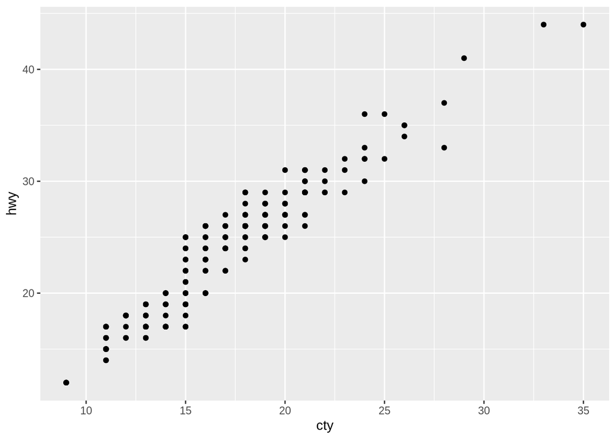

   ```r
   ggplot(data = mpg, mapping = aes(x = cty, y = hwy)) +
     geom_point()
   ```

   Answer: datapoints are being masked by the fact that they have the same value. Could be improved by adding jitter.

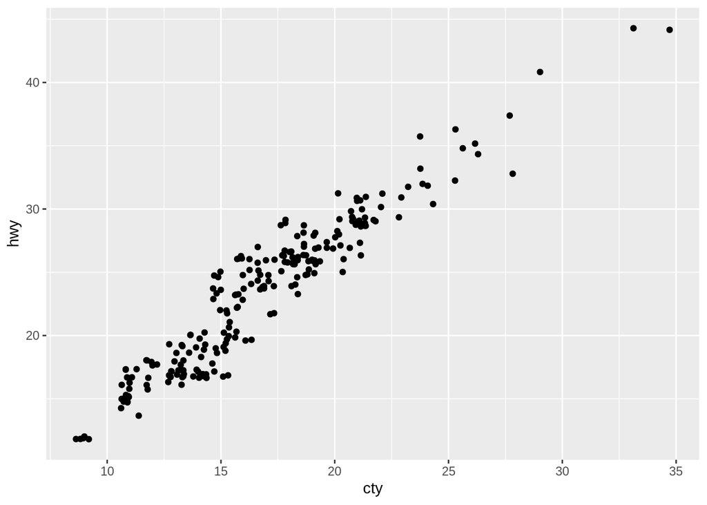

   ```r
   ggplot(data = mpg, mapping = aes(x = cty, y = hwy)) +
     geom_point(position = "jitter")
   ```

2. What parameters to `geom_jitter()` control the amount of jittering?

   Answer: The amount of jitter can be controlled by the position argument.
3. Compare and contrast `geom_jitter()` with `geom_count()`.

   Answer: both are used to handle overlapping points. Geom_jitter adds noise to create artificial separation, Geom_count uses a different marker to denote overlap

# Exercise 6

1. Turn a stacked bar chart into a pie chart using `coord_polar()`.

   Answer:

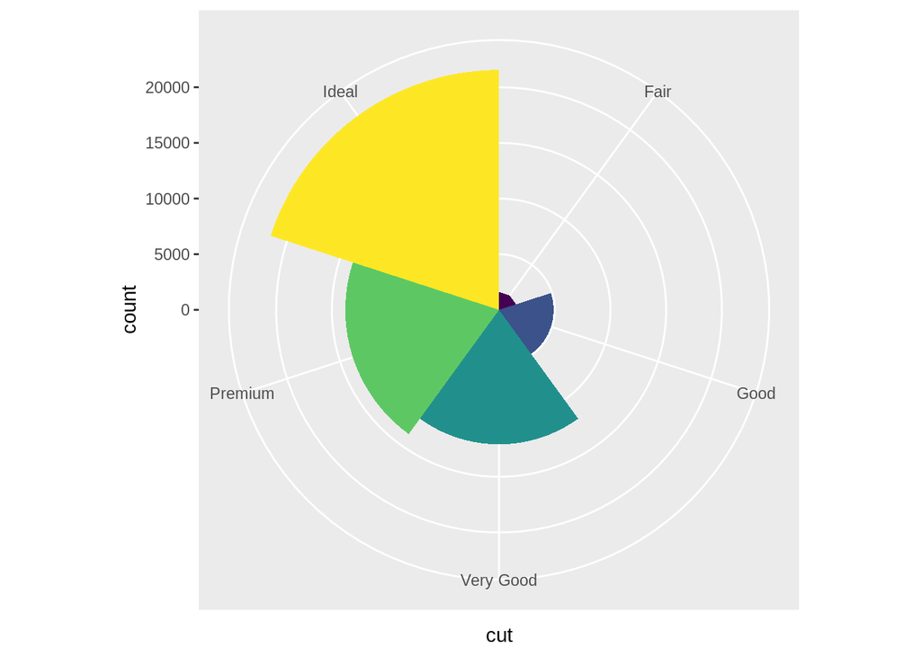

   ```r
     bar <- ggplot(data = diamonds) +
       geom_bar( mapping = aes(x = cut, fill = cut),
       show.legend = FALSE,
       width = 1 )
     bar + coord_polar()
   ```

2. What does `labs()` do? Read the documentation.

   Answer: Allows for customization of axis legend and title elements of a plot.
3. What does the plot below tell you about the relationship between city and highway mpg? Why is `coord_fixed()` important? What does `geom_abline()` do?

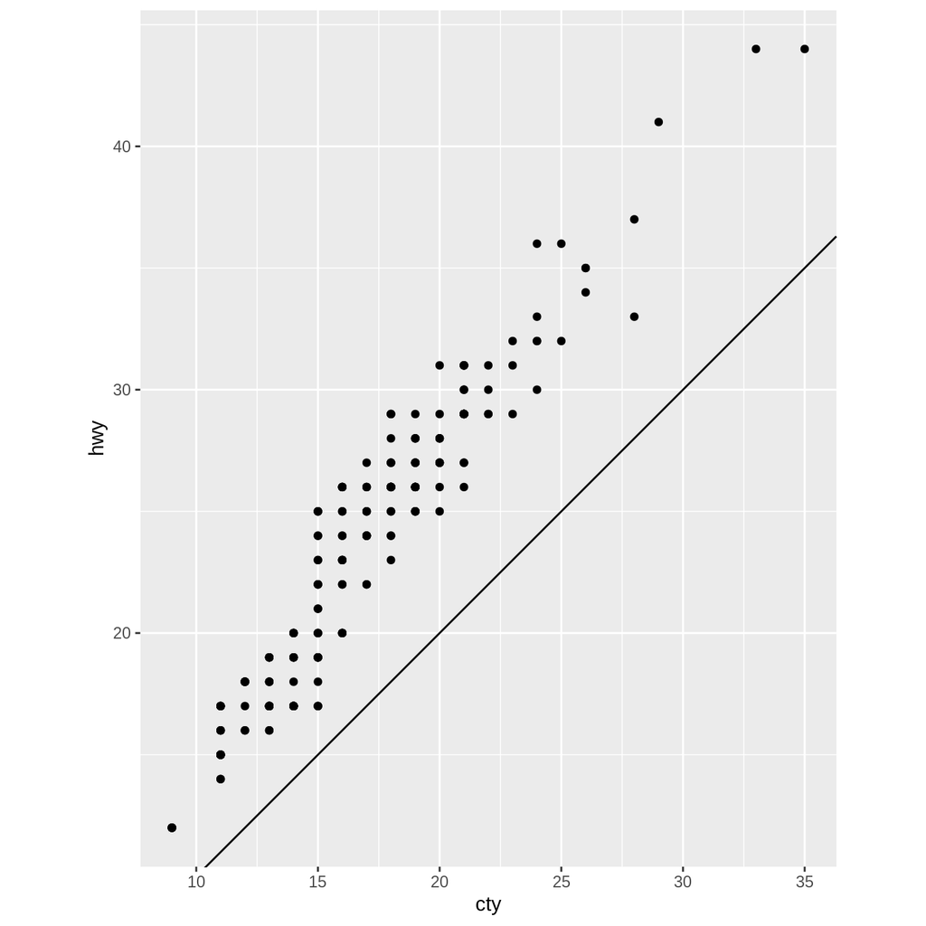

   ```r
   ggplot(data = mpg, mapping = aes(x = cty, y = hwy)) +
     geom_point() +
     geom_abline() +
     coord_fixed()
   ```

   Answer: *coord_fixed()* is important because R would try to scale the axis to have a plot with an aspect ratio of 1. This is misleading if one does not pay close enough attention to the units of the axis. Fixing the aspect ration allows the user to clearly see the that highway miles is higher than city at all points. *geom_abline* creates a straight reference line which can be imformative to put data into context.